# Analysis of Seasonality

# Setup

Common functions

```r
# Returns the bigger date vector of to given vectors. Requires date vector in format %Y %j.
get_bigger_date_vector <- function(date1, date2) {
  if(date1[1] > date2[1]){
    return(date1)
  }else if(date1[1] < date2[1]){
    return(date2)
  }else{
    if(date1[2] > date2[2]){
      return(date1)
    }else if(date1[2] < date2[2]){
      return(date2)
    }else{
      return(date1)
    }
  }
}
# Returns the smaller date vector of to given vectors. Requires date vector in format %Y %j.
get_smaller_date_vector <- function(date1, date2){
  result <- get_bigger_date_vector(date1, date2)
  if (result == date1){
    return(date2)
  }else{
    return(date1)
  }
}
# Allows for each row functionality on dataframes.
rows = function(tab) lapply(
  seq_len(nrow(tab)),
  function(i) unclass(tab[i,,drop=F])
)
```

# Preparation

## Loading

The top 50 currencies by market cap are stored as timeseries in a dictionary like structure in the file.

```r
tso.top50 <- readRDS(file = "tso.top50.rds")
```

## Trimming

Not all timeseries have exactly the same start and end date. Finding the last possible start date and the earliest possible end date is done in the next chunk.

```r
max_start_date <- c(1970, 1)
min_end_date <- c(2999, 300)
for (currency in tso.top50$keys()) {
  currency.ts <- tso.top50$get(currency)
  max_start_date <- get_bigger_date_vector(start(currency.ts), max_start_date)
  min_end_date <- get_smaller_date_vector(end(currency.ts), min_end_date)
}
```

After we have found said dates, we can then now trim the timeseries to those dates. All timeseries should have the same dimensions after this.

```r
currency.tsos <- Dict()
length.tso <- 0

for (currency in tso.top50$keys()) {
  currency.ts <- tso.top50$get(currency)
  sub.ts <- window(currency.ts, start=max_start_date, end=min_end_date)
  length.tso <- length(sub.ts)
  currency.tsos$set(currency, sub.ts)
}
```

# Analysis

## Decomposition

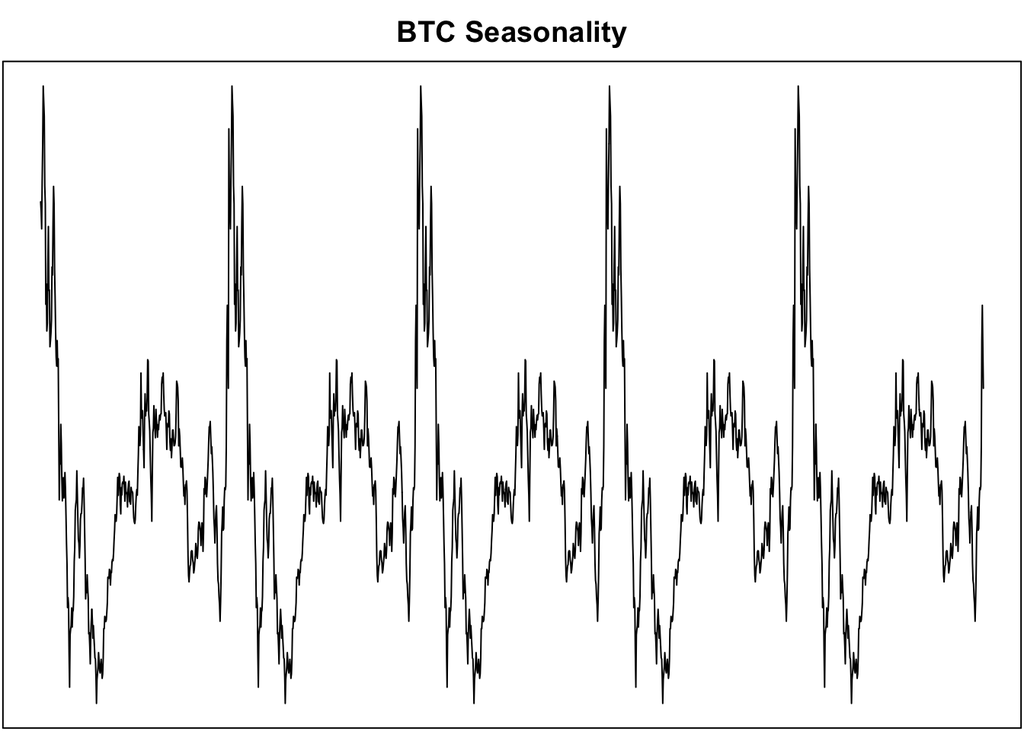

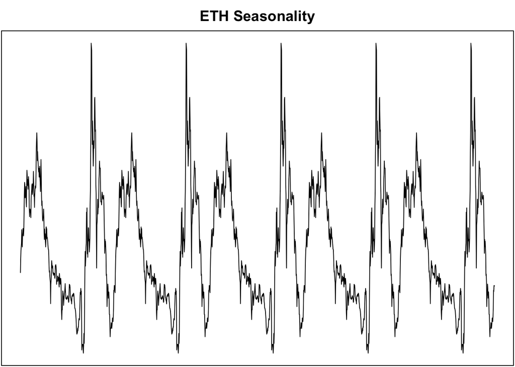

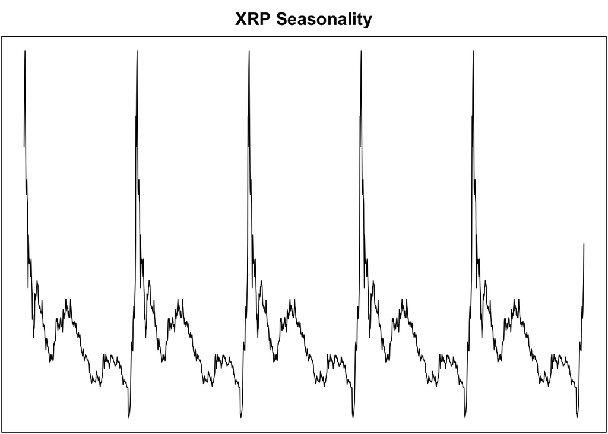

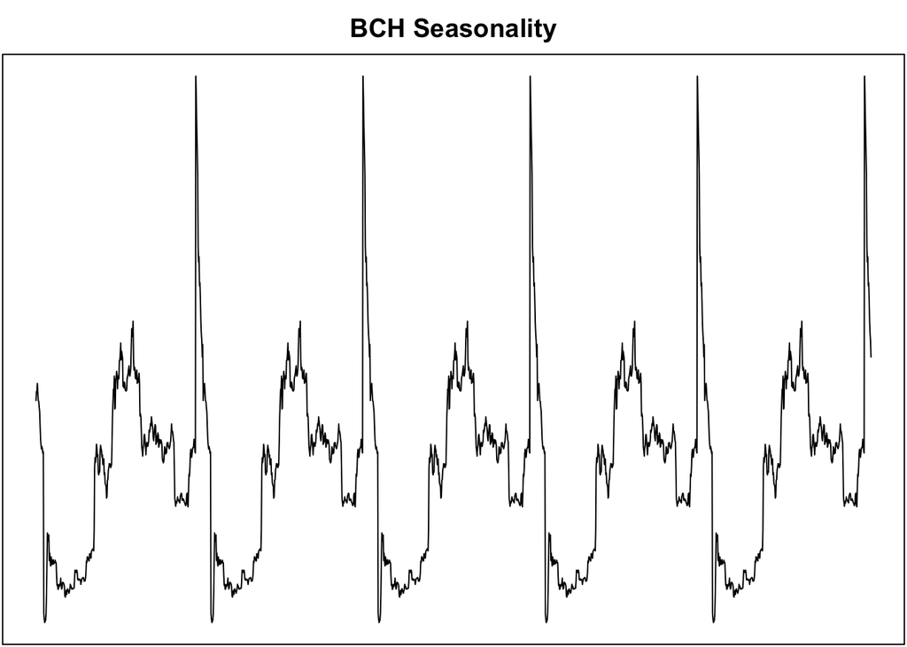

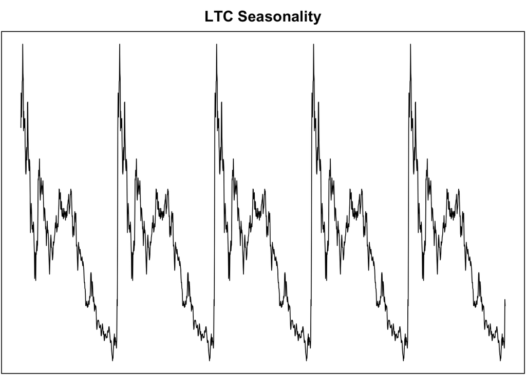

```r
#currencies <- currency.tsos$keys()
currencies <- c('BTC','ETH','XRP','BCH','LTC')
currency.df <- data.frame(matrix(ncol = length(currencies), nrow = length.tso))
colnames(currency.df) <- currencies

# Decompose all currencies
mfrow=c(length(currencies),1)
par(mar=c(0, 0, 2, 0) + 0.1)
for (currency in currencies){
  decomposed <- stl(currency.tsos$get(currency), s.window='periodic', na.action = na.omit)
  seasonal.part <- as.numeric(decomposed$time.series[,'seasonal'])
  plot(seasonal.part, main=paste(currency, 'Seasonality'), ylab='',xlab='', xaxt='n', yaxt='n', type='l')
  seasonal.part.max <- max(seasonal.part)
  seasonal.part.min <- min(seasonal.part)
  #currency.df[currency] <- as.numeric(decomposed$time.series[,'seasonal'])
  # normalize data to -1 and 1
  #currency.df[currency] <- 2 * ((seasonal.part - seasonal.part.min)/(seasonal.part.max - seasonal.part.min)) - 1
  # normalize data to 0 and 1
  currency.df[currency] <- (((seasonal.part - seasonal.part.min)/(seasonal.part.max - seasonal.part.min)))
}
```

```r
par(mar=c(5, 4, 4, 2) + 0.1)
```

## Windowing

The seasonality of a timeseries is always 0 centered. Thus, it would allow us to compare all seasonal components of the currencies. The idea is, that if there are days which influenced the whole crypto market, then we would see those in the seasonal components by them acting similar.

```r
# Calculate some stats row wise.
currency.df <- transform(currency.df, row.sd=apply(currency.df, 1, sd, na.rm=TRUE))
currency.df <- transform(currency.df, row.mean=apply(currency.df, 1, mean, na.rm=TRUE))
```

Finding an optimal threshold for the standard deviation.

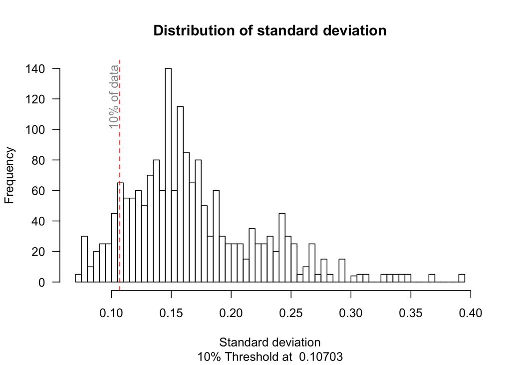

```r
limit <- quantile(currency.df$row.sd, .1)
hist(currency.df$row.sd,
     breaks=50, main = '', xlab='',las=1)
title(main='Distribution of standard deviation', sub=paste('10% Threshold at ', round(limit,5)), xlab='Standard deviation')
abline(v=limit, col='red', lty=2)
text(limit, 100, '10% of data', srt=90, col = "gray60", adj = c(0, -.20))
```

In our analysis, we consider days as impactful or common amongst the currencies, if the standard deviation accross currencies of a given day, does not exceed a certain limit (window).

```r
sd.limit <- limit
currency.df <- mutate(currency.df, in.window = seq(from=FALSE, by=FALSE,length.out =  length.tso))

currency.df$in.window <- apply(currency.df,1, function(row) { row[['row.sd']] <= sd.limit} )
```

We can have a look at the days which are in the window or outside of the window. For the sake of simplicity we are looking at the top 5 currencies.

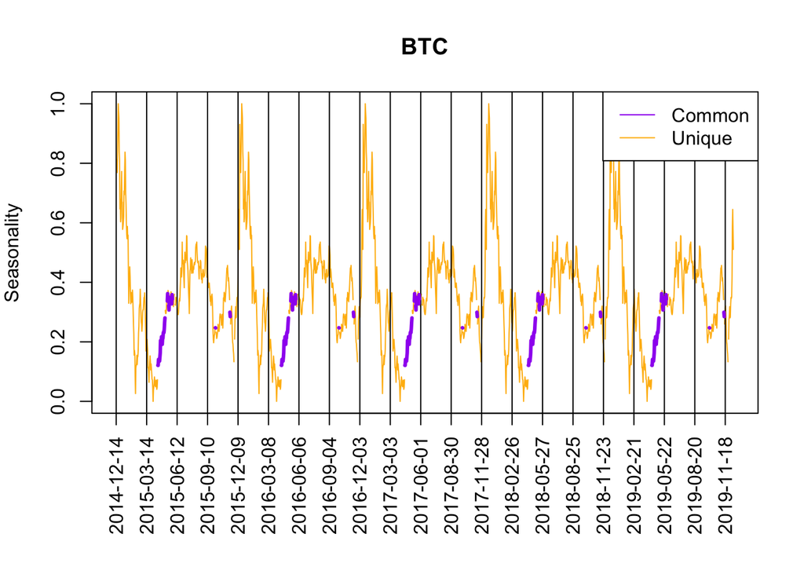

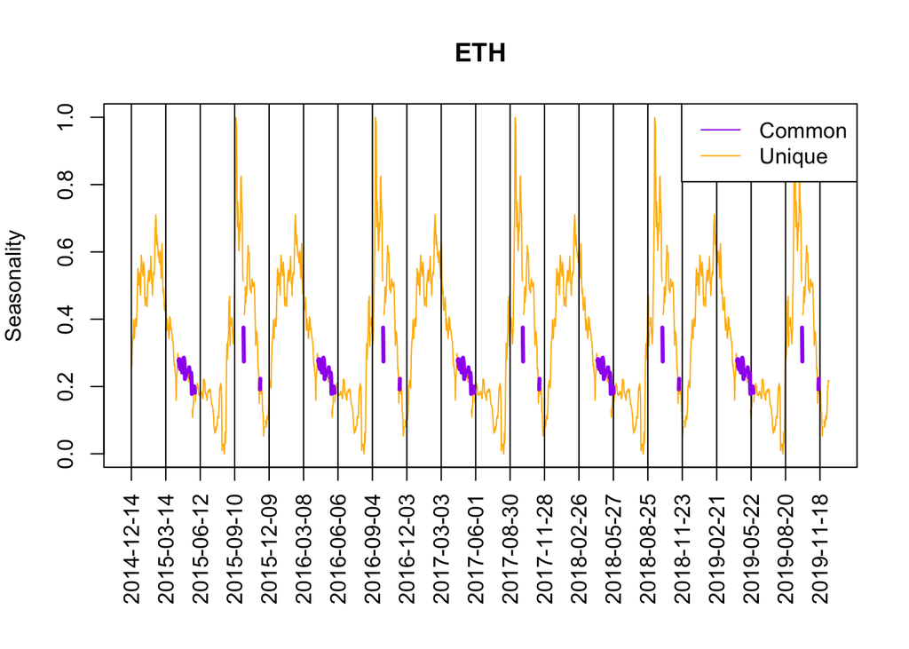

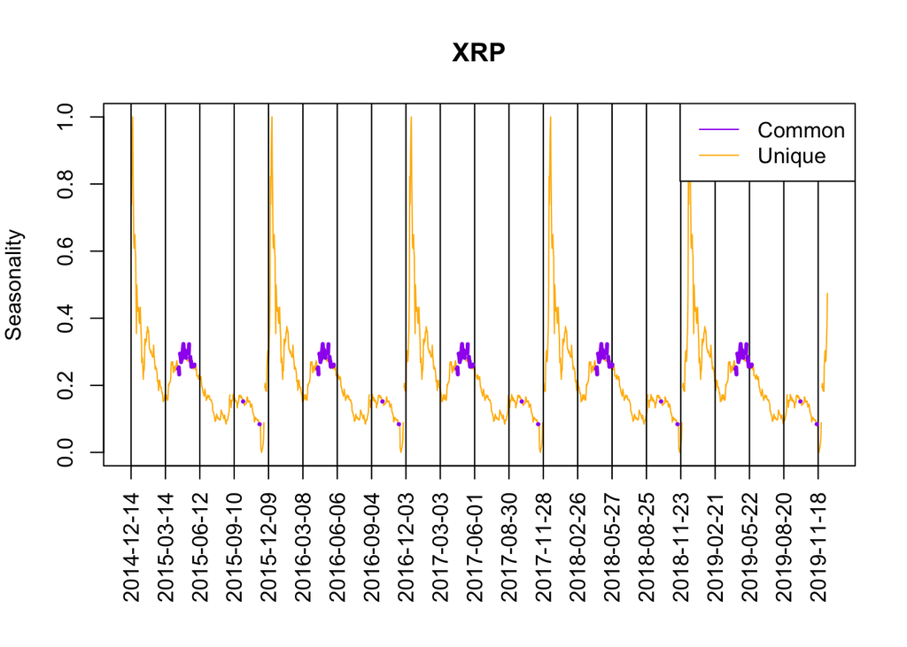

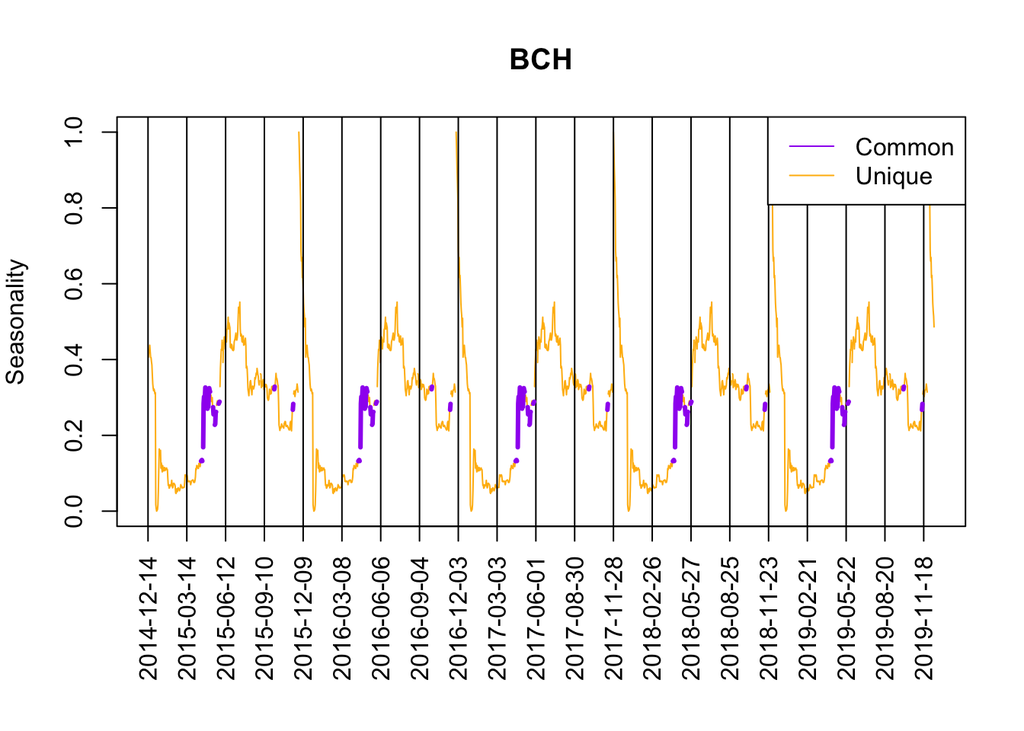

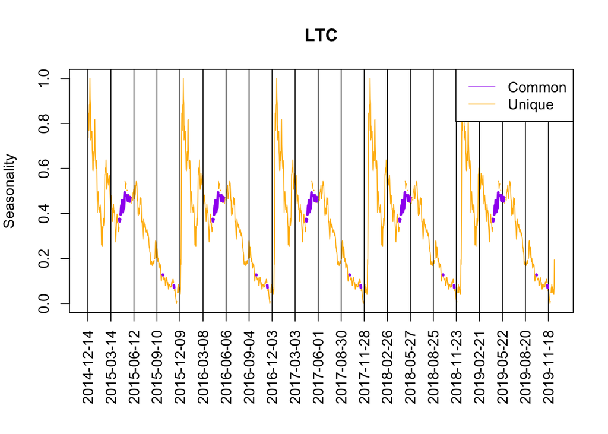

```r
mfrow=c(length(currencies),1)
for(ccy in currencies) {
  row.names(currency.df) <- seq(from = as.Date(toString(max_start_date), '%Y, %j'), by = "day", length.out = length.tso)
  rn <- row.names(currency.df)
  plot.data.out.window <- data.frame(matrix(ncol = 1, nrow = length.tso))
  plot.data.in.window <- data.frame(matrix(ncol = 1, nrow = length.tso))
  row.names(plot.data.out.window) <- rn
  row.names(plot.data.in.window) <- rn
  colnames(plot.data.out.window) <- c(ccy)
  colnames(plot.data.in.window) <- c(ccy)

  currency.df.bkp <- currency.df
  currency.df[currency.df$in.window == TRUE,][[ccy]] <- NA
  plot.data.out.window[[ccy]] <- currency.df[[ccy]]
  currency.df <- currency.df.bkp
  currency.df[currency.df$in.window == FALSE,][[ccy]] <- NA
  plot.data.in.window[[ccy]] <- currency.df[[ccy]]
  currency.df <- currency.df.bkp

  par(mar=c(7,4,4,2))
  day.interval <- 90
  plot(plot.data.out.window[[ccy]],
       type='l',
       main=ccy,
       col='darkgoldenrod1',
       lwd=1,
       ylab = 'Seasonality',
       xaxt = 'n', xlab=''
       )
  axis(1, at=seq(from = 0, to = length.tso, by = day.interval), labels=rn[seq(1,length(rn), day.interval)], las=2)
  abline(v=seq(from = 0, to = length.tso, by = day.interval))
  lines(plot.data.in.window[[ccy]], col='purple', lwd=3)
  legend('topright', legend=c('Common', 'Unique'), col=c('purple', 'darkgoldenrod1'), lty=1)
}
```